# Лабораторная работа №3

Адресация IPv4 и IPv6

Акунаева Антонина Эрдниевна

Российский университет дружбы народов, Москва, Россия

2026-10-10

# Информация

## Докладчик

- Акунаева Антонина Эрдниевна
- студент ФФМиЕН, НПИбд-02-24
- Российский университет дружбы народов
- 1032240492@rudn.ru
- https://github.com/Akuxee

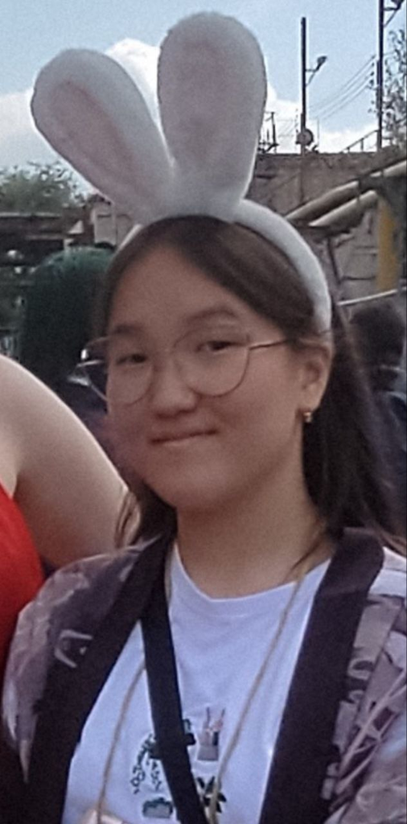

# Цели и задачи

- Изучение принципов организации адресного пространства.

**3.3.1.1. Разбиение IPv4-сети на подсети**

1. Задана IPv4-сеть 172.16.20.0/24. Для заданной сети определите префикс, маску, broadcast-адрес, число возможных подсетей, диапазон адресов узлов. Разбейте сеть на 3 подсети с максимально возможным числом адресов узлов 126, 62, 62 соответственно.
2. Задана сеть 10.10.1.64/26. Для заданной сети определите префикс, маску, broadcast-адрес, число возможных подсетей, диапазон адресов узлов. Выделите в этой сети подсеть на 30 узлов. Запишите характеристики для выделенной подсети.
3. Задана сеть 10.10.1.0/26. Для этой сети определите префикс, маску, broadcast-адрес, число возможных подсетей, диапазон адресов узлов. Выделите в этой сети подсеть на 14 узлов. Запишите характеристики для выделенной подсети.

# Цели и задачи

**3.3.1.2. Разбиение IPv6-сети на подсети**

1. Задана сеть 2001:db8:c0de::/48. Охарактеризуйте адрес, определите маску, префикс, диапазон адресов для узлов сети (краевые значения). Разбейте сеть на 2 подсети двумя способами — с использованием идентификатора подсети и с использованием идентификатора интерфейса. Поясните предложенные вами варианты разбиения.
2. Задана сеть 2a02:6b8::/64. Охарактеризуйте адрес, определите маску, префикс, диапазон адресов для узлов сети (краевые значения). Разбейте сеть на 2 подсети двумя способами — с использованием идентификатора подсети и с использованием идентификатора интерфейса. Поясните предложенные вами варианты разбиения.

# Материалы и методы

- Linux Fedora Workstation (Markdown)
- Google Таблицы

# Выполнение лабораторной работы

## IPv4: Задание 1

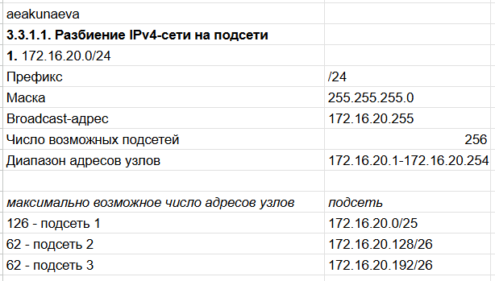

## IPv4: Задание 2

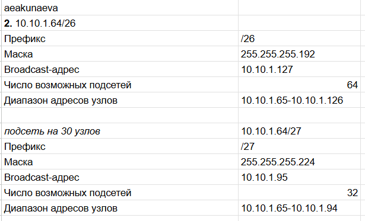

## IPv4: Задание 3

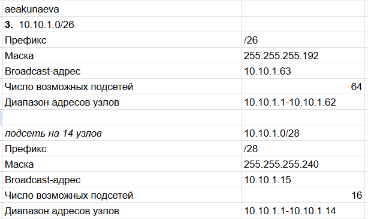

## IPv6: Задание 1

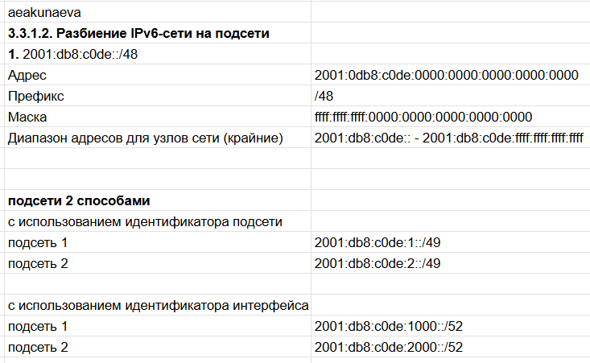

## IPv6: Задание 2

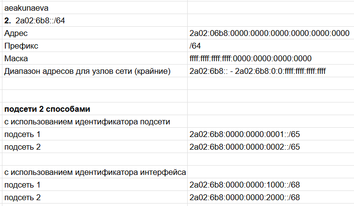

# Выводы

Я изучила принципы организации адресного пространства.